# Giro Roadbook Stats

Jan Schubert

2019-05-16

In this blog post I will be looking at different stats from Giro roadbook(s). If you enjoy it and would like to play with the data more, you can download the whole package including the data and all the reports with `devtools::install_github("schubertjan/giro2019")`.

## May 16

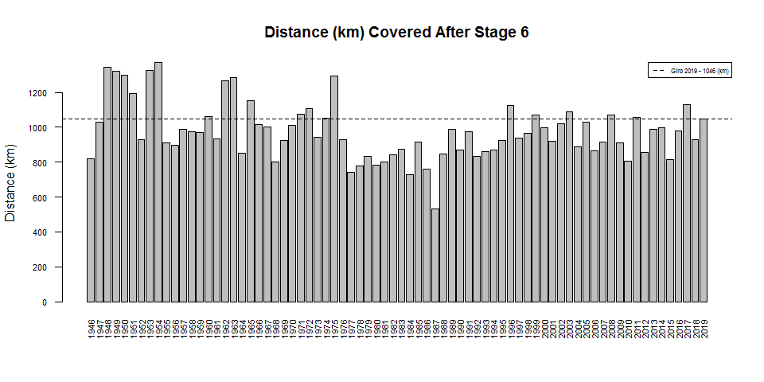

```r
#scrape data from wiki
stages <- stage.scrape()

#calculate cummulative sum after stage 6
dist.after.6 <- sapply(stages, function(x){
  x <- x[!is.na(x[, 4]), ]
  d <- x[, 4]
  cumsum(d)[6]
})

#plot
barplot(height = dist.after.6,
        names.arg = names(dist.after.6),
        main = "Distance (km) Covered After Stage 6",
        ylab = "Distance (km)",
        cex.names = .7,
        cex.axis = .7,
        las=2)
abline(h = tail(dist.after.6,1), lty = 2)
legend("topright", legend = c("Giro 2019 - 1046 (km)"), lty = 2, cex = .5)
```

## May 12

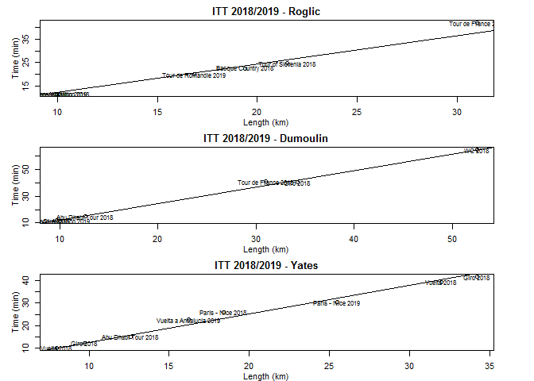

```r
dat <- list(Roglic = tt[tt$rider == "Roglic", ],
            Dumoulin = tt[tt$rider == "Dumoulin", ],
            Yates = tt[tt$rider == "Yates S.", ])

#we will remove tour de romandie 2018 ITT as that was uphill and an outlier
dat$Roglic <- dat$Roglic[- c(5), ]

par(mfrow = c(3,1), mar = c(3,4,2,4))
x <- lapply(1:length(dat), function(i) {
  d <- dat[[i]]
  plot(d$len, d$time,
       xlab = "",
       ylab = "",
       main = paste0("ITT 2018/2019 - ", names(dat)[i]))
  abline(lm(time ~ len -1, data = d, w = 1/d$len))
  text(d$len, d$time,labels = d$race, cex = .8)
  title(ylab="Time (min)", xlab = "Length (km)", line=2)
})
```

```r
#we will remove tour de romandie 2018 ITT as that was uphill and an outlier
m <- list(roglic_m = lm(time ~ len - 1, data = dat$Roglic, w = 1/dat$Roglic$len),
          dumoulin_m = lm(time ~ len - 1, data = dat$Dumoulin, w = 1/dat$Dumoulin$len),
          yates_m = lm(time ~ len - 1, data = dat$Yates, w = 1/dat$Yates$len))
lapply(m, summary)
```

```
#> $roglic_m
#>
#> Call:
#> lm(formula = time ~ len - 1, data = dat$Roglic, weights = 1/dat$Roglic$len)
#>
#> Weighted Residuals:
#>       1       2       3       4       6       7
#> -0.1299 -0.1787  0.7814 -0.2999 -0.2655 -0.2188
#>
#> Coefficients:
#>     Estimate Std. Error t value Pr(>|t|)
#> len  1.21663    0.03995   30.46 7.16e-07 ***
#> ---
#> Signif. codes:  0 '***' 0.001 '**' 0.01 '*' 0.05 '.' 0.1 ' ' 1
#>
#> Residual standard error: 0.4166 on 5 degrees of freedom
#> Multiple R-squared:  0.9946, Adjusted R-squared:  0.9936
#> F-statistic: 927.6 on 1 and 5 DF,  p-value: 7.16e-07
#>
#>
#> $dumoulin_m
#>
#> Call:
#> lm(formula = time ~ len - 1, data = dat$Dumoulin, weights = 1/dat$Dumoulin$len)
#>
#> Weighted Residuals:
#>         8         9        10        11        12        13
#> -0.237834 -0.003941  0.508838 -0.272365  0.042529 -0.166802
#>
#> Coefficients:
#>     Estimate Std. Error t value Pr(>|t|)
#> len  1.22689    0.02364   51.89 5.03e-08 ***
#> ---
#> Signif. codes:  0 '***' 0.001 '**' 0.01 '*' 0.05 '.' 0.1 ' ' 1
#>
#> Residual standard error: 0.2896 on 5 degrees of freedom
#> Multiple R-squared:  0.9981, Adjusted R-squared:  0.9978
#> F-statistic:  2692 on 1 and 5 DF,  p-value: 5.026e-08
#>
#>
#> $yates_m
#>
#> Call:
#> lm(formula = time ~ len - 1, data = dat$Yates, weights = 1/dat$Yates$len)
#>
#> Weighted Residuals:
#>      Min       1Q   Median       3Q      Max
#> -0.35432 -0.22788 -0.08575  0.16173  0.66423
#>
#> Coefficients:
#>     Estimate Std. Error t value Pr(>|t|)
#> len  1.26363    0.03041   41.55 1.22e-09 ***
#> ---
#> Signif. codes:  0 '***' 0.001 '**' 0.01 '*' 0.05 '.' 0.1 ' ' 1
#>
#> Residual standard error: 0.3805 on 7 degrees of freedom
#> Multiple R-squared:  0.996,  Adjusted R-squared:  0.9954
#> F-statistic:  1727 on 1 and 7 DF,  p-value: 1.219e-09
```

```r
pred <- sapply(m, predict, data.frame(len = c(5.9)))
obs <- c("6:48", "7:06", "6:59")
s <-  as.numeric(format(strptime(obs, format = "%M:%S"), format = "%S")) * 1/60^2
m <-  as.numeric(format(strptime(obs, format = "%M:%S"), format = "%M")) * 1/60
t <- (m+s)*60

(t - pred)*60/100
```

```
#>   roglic_m.1 dumoulin_m.1    yates_m.1
#>  -0.22686081  -0.08317566  -0.28323254
```

```r
t/pred
```

```
#>   roglic_m.1 dumoulin_m.1    yates_m.1
#>    0.9473257    0.9808491    0.9366828
```

## May 10

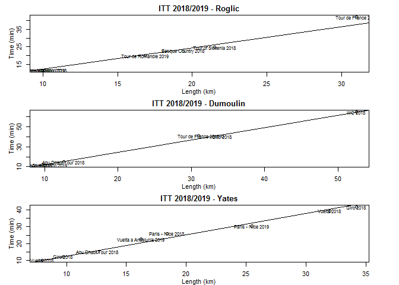

```r
dat <- list(Roglic = tt[tt$rider == "Roglic", ],
            Dumoulin = tt[tt$rider == "Dumoulin", ],
            Yates = tt[tt$rider == "Yates S.", ])

#we will remove tour de romandie 2018 ITT as that was uphill and an outlier
dat$Roglic <- dat$Roglic[- c(5), ]

par(mfrow = c(3,1), mar = c(3,4,2,4))
x <- lapply(1:length(dat), function(i) {
  d <- dat[[i]]
  plot(d$len, d$time,
       xlab = "",
       ylab = "",
       main = paste0("ITT 2018/2019 - ", names(dat)[i]))
  abline(lm(time ~ len -1, data = d, w = 1/d$len))
  text(d$len, d$time,labels = d$race, cex = .8)
  title(ylab="Time (min)", xlab = "Length (km)", line=2)
})
```

```r
#we will remove tour de romandie 2018 ITT as that was uphill and an outlier
m <- list(roglic_m = lm(time ~ len - 1, data = dat$Roglic, w = 1/dat$Roglic$len),
          dumoulin_m = lm(time ~ len - 1, data = dat$Dumoulin, w = 1/dat$Dumoulin$len),
          yates_m = lm(time ~ len - 1, data = dat$Yates, w = 1/dat$Yates$len))
lapply(m, summary)
```

```
#> $roglic_m
#>
#> Call:
#> lm(formula = time ~ len - 1, data = dat$Roglic, weights = 1/dat$Roglic$len)
#>
#> Weighted Residuals:
#>       1       2       3       4       6       7
#> -0.1299 -0.1787  0.7814 -0.2999 -0.2655 -0.2188
#>
#> Coefficients:
#>     Estimate Std. Error t value Pr(>|t|)
#> len  1.21663    0.03995   30.46 7.16e-07 ***
#> ---
#> Signif. codes:  0 '***' 0.001 '**' 0.01 '*' 0.05 '.' 0.1 ' ' 1
#>
#> Residual standard error: 0.4166 on 5 degrees of freedom
#> Multiple R-squared:  0.9946, Adjusted R-squared:  0.9936
#> F-statistic: 927.6 on 1 and 5 DF,  p-value: 7.16e-07
#>
#>
#> $dumoulin_m
#>
#> Call:
#> lm(formula = time ~ len - 1, data = dat$Dumoulin, weights = 1/dat$Dumoulin$len)
#>
#> Weighted Residuals:
#>         8         9        10        11        12        13
#> -0.237834 -0.003941  0.508838 -0.272365  0.042529 -0.166802
#>
#> Coefficients:
#>     Estimate Std. Error t value Pr(>|t|)
#> len  1.22689    0.02364   51.89 5.03e-08 ***
#> ---
#> Signif. codes:  0 '***' 0.001 '**' 0.01 '*' 0.05 '.' 0.1 ' ' 1
#>
#> Residual standard error: 0.2896 on 5 degrees of freedom
#> Multiple R-squared:  0.9981, Adjusted R-squared:  0.9978
#> F-statistic:  2692 on 1 and 5 DF,  p-value: 5.026e-08
#>
#>
#> $yates_m
#>
#> Call:
#> lm(formula = time ~ len - 1, data = dat$Yates, weights = 1/dat$Yates$len)
#>
#> Weighted Residuals:
#>      Min       1Q   Median       3Q      Max
#> -0.35432 -0.22788 -0.08575  0.16173  0.66423
#>
#> Coefficients:
#>     Estimate Std. Error t value Pr(>|t|)
#> len  1.26363    0.03041   41.55 1.22e-09 ***
#> ---
#> Signif. codes:  0 '***' 0.001 '**' 0.01 '*' 0.05 '.' 0.1 ' ' 1
#>
#> Residual standard error: 0.3805 on 7 degrees of freedom
#> Multiple R-squared:  0.996,  Adjusted R-squared:  0.9954
#> F-statistic:  1727 on 1 and 7 DF,  p-value: 1.219e-09
```

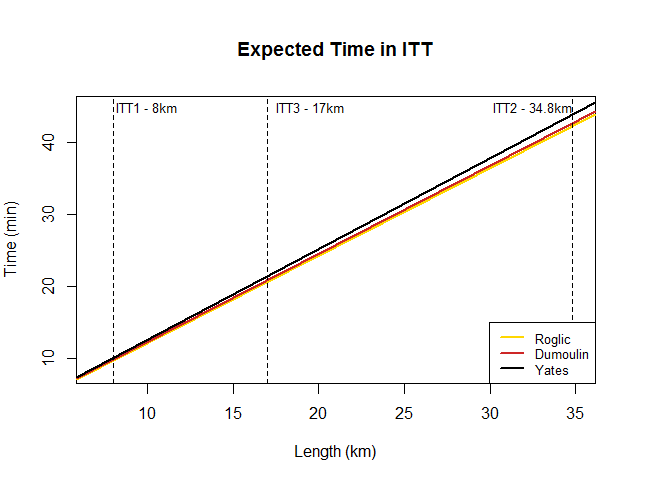

```r
par(mfrow = c(1,1), mar = c(5,4,5,4))
plot(c(7,35), c(8,45),
     type = "n",
     xlab = "Length (km)",
     ylab = "Time (min)",
     main = "Expected Time in ITT")
abline(m$roglic_m, col = "gold", lwd = 2)
abline(m$dumoulin_m, col = "firebrick3", lwd = 2)
abline(m$yates_m, col = "black", lwd = 2)
abline(v = c(8,34.8,17), lty = 2)
text(10,45,labels = "ITT1 - 8km", cex = .8)
text(32.5,45,labels = "ITT2 - 34.8km", cex = .8)
text(19.5,45,labels = "ITT3 - 17km", cex = .8)
legend("bottomright",
       legend = c("Roglic", "Dumoulin", "Yates"),
       col = c("gold", "firebrick3", "black"),
       lwd = c(2,2,2),
       cex = .8)
```

```r
out <- sapply(m, predict, data.frame(len = c(8,34.8,17)))
m <- round( floor((out %% 1)*100) * 0.6, 0)
m <- ifelse(nchar(m) == 1, paste0("0",m),m)
out_print <- matrix(paste0(floor(out),
                           ":",
                           m),
                    ncol = 3,
                    nrow = 3)
#out_print <- as.data.frame(out_print)
colnames(out_print) <- c("Roglic", "Dumoulin", "Yates")
row.names(out_print) <- c("ITT1", "ITT2", "ITT3")
knitr::kable(out_print)
```

|  | Roglic | Dumoulin | Yates |
| --- | --- | --- | --- |
| ITT1 | 9:44 | 9:49 | 10:06 |
| ITT2 | 42:20 | 42:41 | 43:58 |
| ITT3 | 20:41 | 20:51 | 21:29 |

```r
out_diff <- apply(out, 2, function(x) out[, 3]-x)
out_diff <- as.data.frame(out_diff[, -3])
out_diff[4, ] <- colSums(out_diff)
out_diff <- as.matrix(out_diff)
m <- round(floor((out_diff %% 1)*100) * 0.6, 0)
m <- ifelse(nchar(m) == 1, paste0("0",m),m)
out_d_print <- matrix(paste0(floor(out_diff),
                           ":",
                           m),
                    ncol = 2,
                    nrow = 4)
colnames(out_d_print) <- c("Roglic", "Dumoulin")
row.names(out_d_print) <- c("ITT1", "ITT2", "ITT3", "Total")
knitr::kable(out_d_print)
```

|  | Roglic | Dumoulin |
| --- | --- | --- |
| ITT1 | 0:22 | 0:17 |
| ITT2 | 1:38 | 1:16 |
| ITT3 | 0:47 | 0:37 |
| Total | 2:49 | 2:11 |

## May 7

Today’s data comes from Giro road book and has been downloaded using the tabulizer package: `tabulizer::extract_tables("http://www.giroditalia.it/wp-content/uploads/2019/04/Garibaldi_Giro_italia_2019_low_res.pdf", pages = c(17, 18))`

`tabulizer::extract_tables("https://static2.giroditalia.it/wp-content/uploads/2017/04/Garibaldi_2017.pdf", pages = c(10))`

`tabulizer::extract_tables("https://legaciclismo.files.wordpress.com/2018/05/garibaldi-2018.pdf", pages = c(19, 20))`

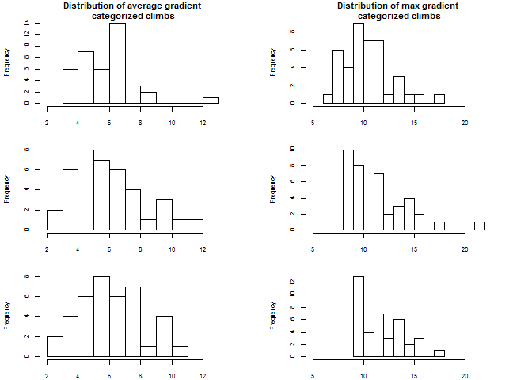

```r
par(mfcol = c(3,2), mar = c(2,4,2,4))
hist(climbs_2017$p.media,
     breaks = 10,
     xlim = c(2, 13),
     cex.main = 1,
     cex.lab = .8,
     cex.axis = .8,
     xlab = "Average Gradient",
     main = "Distribution of average gradient\n categorized climbs")
hist(climbs_2018$p.media,
     breaks = 10,
     xlim = c(2, 13),
     cex.main = 1,
     cex.lab = .8,
     cex.axis = .8,
     main = "")
hist(climbs$p.med,
     breaks = 10,
     xlim = c(2, 13),
     cex.main = 1,
     cex.lab = .8,
     cex.axis = .8,
     main = "")

hist(climbs_2017$p.max,
     breaks = 10,
     xlim = c(5, 22),
     cex.main = 1,
     cex.lab = .8,
     cex.axis = .8,
     xlab = "Max Gradient",
     main = "Distribution of max gradient\n categorized climbs")
hist(climbs_2018$p.max,
     breaks = 10,
     xlim = c(5, 22),
     cex.main = 1,
     cex.lab = .8,
     cex.axis = .8,
     main = "")
hist(climbs$p.max,
     breaks = 10,
     xlim = c(5, 22),
     cex.main = 1,
     cex.lab = .8,
     cex.axis = .8,
     main = "")
```

```r
l <- list(giro_2017 = climbs_2018[, c("length.km", "p.media","p.max")],
          giro_2018 = climbs_2017[, c("length.km", "p.media","p.max")],
          giro_2019 = climbs[, c("lungh.(km)", "p.med","p.max")]
          )
lapply(l, function(x) summary(x)[4, ])
```

```
#> $giro_2017
#>          length.km            p.media              p.max
#> "Mean   : 9.454  " "Mean   : 5.915  "  "Mean   :11.87  "
#>
#> $giro_2018
#>          length.km            p.media              p.max
#>  "Mean   :11.27  " "Mean   : 5.785  "  "Mean   :10.85  "
#>
#> $giro_2019
#>         lungh.(km)              p.med              p.max
#> "Mean   : 9.485  " "Mean   : 6.251  "   "Mean   :12.1  "
```

## May 5

Today’s data comes from Giro road book and has been downloaded using the tabulizer package: `tabulizer::extract_tables("http://www.giroditalia.it/wp-content/uploads/2019/04/Garibaldi_Giro_italia_2019_low_res.pdf", pages = c(17, 18))`

`tabulizer::extract_tables("https://static2.giroditalia.it/wp-content/uploads/2017/04/Garibaldi_2017.pdf", pages = c(10))`

`tabulizer::extract_tables("https://legaciclismo.files.wordpress.com/2018/05/garibaldi-2018.pdf", pages = c(19, 20))`

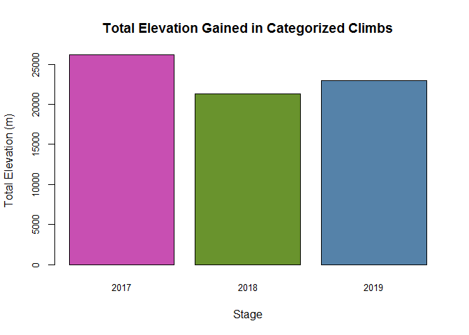

```r
#fill the data with all stages
fill <- data.frame(tappa = 1:21)
climbs_2019 <- merge(fill, climbs, by = "tappa", all.x = TRUE)
fill <- data.frame(stage = 1:21)
climbs_2018 <- merge(fill, climbs_2018, by = "stage", all.x = TRUE)
climbs_2017 <- merge(fill, climbs_2017, by = "stage", all.x = TRUE)

#replace NA
climbs_2019$`disl.(m)` <- ifelse(is.na(climbs_2019$`disl.(m)`), 0, climbs_2019$`disl.(m)`)
climbs_2018$disl.m <- ifelse(is.na(climbs_2018$disl.m), 0, climbs_2018$disl.m)
climbs_2017$disl.m <- ifelse(is.na(climbs_2017$disl.m), 0, climbs_2017$disl.m)

#create colours
col_2017 <- rgb(200, 79, 178, maxColorValue = 255)
col_2018 <- rgb(105, 147, 45, maxColorValue = 255)
col_2019 <- rgb(85, 130, 169, maxColorValue = 255)

comp <- data.frame(Year = factor(c("2017", "2018", "2019")),
                   Total.elev = c(sum(climbs_2017$disl.m, na.rm = TRUE),
                                  sum(climbs_2018$disl.m, na.rm = TRUE),
                                  sum(climbs_2019$`disl.(m)`, na.rm = TRUE)))
with(comp,barplot(Total.elev,
                  names.arg = Year,
                  xlab = "Stage",
                  ylab = "Total Elevation (m)",
                  main = "Total Elevation Gained in Categorized Climbs",
                  cex.axis = .8,
                  cex.names = .8,
                  col = c(col_2017, col_2018, col_2019)))
```

```r
DT::datatable(comp, rownames = FALSE)
```

| Year | Total.elev |
| --- | --- |
| 2017 | 26157 |
| 2018 | 21274 |
| 2019 | 22954 |

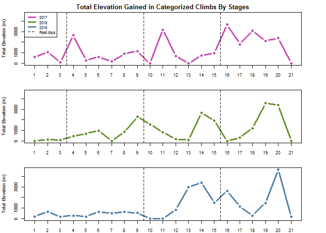

```r
#summary by stage
s_2019 <- with(climbs_2019, tapply(`disl.(m)`, tappa, sum))
s_2018 <- with(climbs_2018, tapply(disl.m, stage, sum))
s_2017 <- with(climbs_2017, tapply(disl.m, stage, sum))

par(mfrow = c(3,1), mar = c(2,4,2,4))
plot(names(s_2017),
     s_2017,
     type = "b",
     lwd = 3,
     col = col_2017,
     ylim = c(0, max(c(s_2017,
                       s_2018,
                       s_2019))),
     main = "Total Elevation Gained in Categorized Climbs By Stages",
     ylab = "Total Elevation (m)",
     xlab = "Stage",
     cex.axis = .85,
     cex.lab = .85,
     cex.main = 1.2,
     xaxt="n",
     pch = 16)
axis(1, labels = names(s_2017), at = names(s_2017), cex.axis = .85)
legend("topleft",
       legend = c("2017", "2018", "2019", "Rest days"),
       col = c(col_2017, col_2018, col_2019, "black"),
       lwd = c(3,3,3,1),
       lty = c(1,1,1,2),
       cex = .8)
abline(v = 3.5, lty = 2)
abline(v = 9.5, lty = 2)
abline(v = 15.5, lty = 2)
plot(names(s_2017),
     s_2018,
     type = "b",
     lwd = 3,
     col = col_2018,
     ylim = c(0, max(c(s_2017,
                       s_2018,
                       s_2019))),
     ylab = "Total Elevation (m)",
     cex.axis = .85,
     cex.lab = .85,
     xaxt="n",
     pch = 16)
axis(1, labels = names(s_2017), at = names(s_2017), cex.axis = .85)
abline(v = 3.5, lty = 2)
abline(v = 9.5, lty = 2)
abline(v = 15.5, lty = 2)
plot(names(s_2017),
     s_2019,
     type = "b",
     lwd = 3,
     col = col_2019,
     ylim = c(0, max(c(s_2017,
                       s_2018,
                       s_2019))),
     ylab = "Total Elevation (m)",
     cex.axis = .85,
     cex.lab = .85,
     xaxt="n",
     pch = 16)
axis(1, labels = names(s_2017), at = names(s_2017), cex.axis = .85)
abline(v = 9.5, lty = 2)
abline(v = 15.5, lty = 2)
```

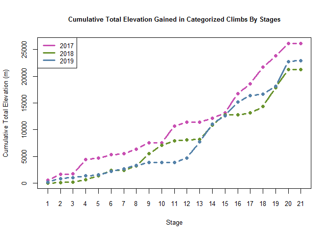

```r
#summary by stage
cs_2017 <- cumsum(s_2017)
cs_2018 <- cumsum(s_2018)
cs_2019 <- cumsum(s_2019)
#replace NA

par(mfrow = c(1,1), mar = c(5,4,4,2))
plot(names(s_2017),
     cs_2017,
     type = "b",
     lwd = 3,
     col = col_2017,
     ylim = c(0, max(c(cs_2017,
                       cs_2018,
                       cs_2019))),
     main = "Cumulative Total Elevation Gained in Categorized Climbs By Stages",
     ylab = "Cumulative Total Elevation (m)",
     xlab = "Stage",
     cex.main = .8,
     cex.axis = .8,
     cex.lab = .8,
     xaxt="n",
     pch = 16)
legend("topleft",
       legend = c("2017", "2018", "2019"),
       col = c(col_2017, col_2018, col_2019),
       lwd = c(3,3,3),
       cex = .8)
lines(cs_2018, lwd = 3, pch = 16,col = col_2018, type = "b")
lines(cs_2019, lwd = 3, pch = 16, col = col_2019, type = "b")
axis(1, labels = names(s_2017), at = names(s_2017), cex.axis = .8)
legend("topleft",
       legend = c("2017", "2018", "2019"),
       col = c(col_2017, col_2018, col_2019),
       lwd = c(3,3,3),
       lty = c(1,1,1),
       cex = .8)
```

```r
DT::datatable(data.frame(giro2017 = s_2017,
                         giro2018 = s_2018,
                         giro2019 = s_2019))
```

|  | giro2017 | giro2018 | giro2019 |
| --- | --- | --- | --- |
| 1 | 600 | 0 | 204 |
| 2 | 1048 | 139 | 668 |
| 3 | 98 | 78 | 185 |
| 4 | 2649 | 469 | 297 |
| 5 | 296 | 711 | 201 |
| 6 | 619 | 978 | 655 |
| 7 | 177 | 0 | 497 |
| 8 | 906 | 856 | 645 |
| 9 | 1141 | 2292 | 549 |
| 10 | 0 | 1556 | 0 |

[output cut: 11 more lines]

## May 4

The data comes from [2019 Giro road book](http://www.giroditalia.it/wp-content/uploads/2019/04/Garibaldi_Giro_italia_2019_low_res.pdf) and has been downloaded using the tabulizer package `tabulizer::extract_tables("http://www.giroditalia.it/wp-content/uploads/2019/04/Garibaldi_Giro_italia_2019_low_res.pdf", pages = c(17, 18))`.

Below is a detailed overview of all classified climbs by stages. The x axis shows the length of a climb (km), the y axis elevation difference (m). All charts use the same axis to allow relative comparison. The colour represents climb’s category.

- Black = cat 1
- Red = cat 2
- Orange = cat 3
- Green = cat 4

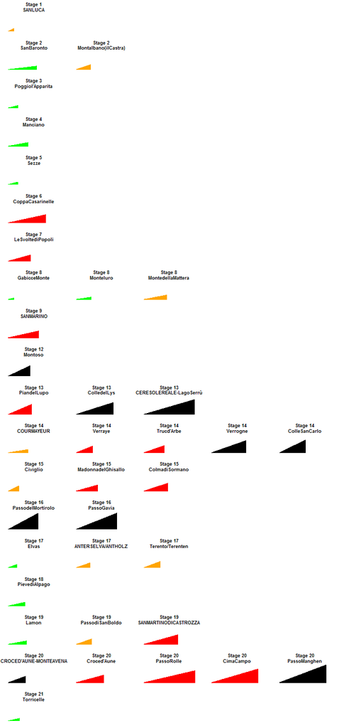

```r
#pre-process data
climbs_l <- split(climbs,climbs$tappa)
n <- lapply(climbs_l,function(x) nrow(x) + 1)
#creare NA for stages with  < 5 climbs
for(i in 1:length(climbs_l)){
  if(n[i] != 6){
    for(j in n[[i]]:5){
      climbs_l[[i]][j, ] <- NA
      }
  }
}
climbs_full <- do.call(rbind, climbs_l)


par(mfrow = c(19,5), mar = c(1,1,2,1))
x <- lapply(1:nrow(climbs_full), function(i) {
  #create data
  x <- c(0, climbs_full$`lungh.(km)`[i])
  y <- c(0, climbs_full$`disl.(m)`[i])
  #if no data plot empty else plot climb
  if(is.na(x[2])) {
      plot(0,0,type = "n", axes = FALSE,ann = FALSE)
  } else {
  dat <- giro2019::createhilldata(x = climbs_full$`lungh.(km)`[i],
                                  y = climbs_full$`disl.(m)`[i],
                                  cat = climbs_full$cat[i])
  giro2019::hillplot(x = dat$x,
                     y = dat$y,
                     col_plot = dat$plot_col,
                     x_lim = max(climbs_full$`lungh.(km)`, na.rm = TRUE),
                     y_lim = max(climbs_full$`disl.(m)`, na.rm = TRUE),
                     stage = climbs_full$tappa[i],
                     climb_name = climbs_full$gpm[i],
                     showaxis = FALSE)
  }
})
```

```r
DT::datatable(climbs[, c(1,4,5,11,12,13)], rownames = FALSE)
```

| tappa | gpm | cat | lungh.(km) | disl.(m) | p.med |
| --- | --- | --- | --- | --- | --- |
| 8 | GabicceMonte | 4 | 2.2 | 113 | 5.1 |
| 8 | Monteluro | 4 | 6 | 180 | 3 |
| 3 | Poggiol'Apparita | 4 | 3.8 | 185 | 4.9 |
| 5 | Sezze | 4 | 3.9 | 201 | 5.2 |
| 1 | SANLUCA | 3 | 2.1 | 204 | 9.7 |
| 21 | Torricelle | 4 | 4.5 | 205 | 4.6 |
| 14 | COURMAYEUR | 3 | 8 | 257 | 3.2 |
| 17 | Elvas | 4 | 3.4 | 259 | 7.6 |
| 2 | SanBaronto | 4 | 11.3 | 273 | 2.4 |
| 19 | Lamon | 4 | 7.4 | 276 | 3.7 |

[output cut: 29 more lines]